# Sparkify Project Workspace

This workspace contains a tiny subset (128MB) of the full dataset available (12GB). Feel free to use this workspace to build your project, or to explore a smaller subset with Spark before deploying your cluster on the cloud. Instructions for setting up your Spark cluster is included in the last lesson of the Extracurricular Spark Course content.

You can follow the steps below to guide your data analysis and model building portion of this project.

```python
# import libraries
import seaborn as sns
from pyspark.sql import SparkSession
from pyspark.sql.functions import udf
from pyspark.sql.types import StringType
from pyspark.sql.types import IntegerType
from pyspark.sql.functions import desc
from pyspark.sql.functions import asc
from pyspark.sql.functions import sum as Fsum
import math
import datetime

from pyspark.sql import Window
import pandas as pd
import numpy as np
from matplotlib import pyplot as plt
%matplotlib inline

import re
from pyspark.sql import functions as sF
from pyspark.sql import types as sT

from functools import reduce

# ML imports
from pyspark.ml.feature import Normalizer, StandardScaler, VectorAssembler
from pyspark.ml.classification import DecisionTreeClassifier, GBTClassifier, LogisticRegression, MultilayerPerceptronClassifier, NaiveBayes, RandomForestClassifier
from pyspark.ml.regression import LinearRegression
from pyspark.ml.evaluation import MulticlassClassificationEvaluator
from pyspark.ml.tuning import CrossValidator, ParamGridBuilder
from pyspark.ml.tuning import CrossValidatorModel as mlm
from pyspark.mllib.evaluation import MulticlassMetrics

from pyspark.mllib.evaluation import MulticlassMetrics
import seaborn as sns
import matplotlib.pyplot as plt

sns.set(style="darkgrid", palette="bright")
from matplotlib import cm
```

```python
# create a Spark session
spark = SparkSession.builder \
                    .master("local") \
                    .appName("Sparkify") \
                    .getOrCreate()
```

# Load and Clean Dataset

In this workspace, the mini-dataset file is `mini_sparkify_event_data.json`. Load and clean the dataset, checking for invalid or missing data - for example, records without userids or sessionids.

```python
df = spark.read.json('medium-sparkify-event-data.json')
df.persist()
```

```
DataFrame[artist: string, auth: string, firstName: string, gender: string, itemInSession: bigint, lastName: string, length: double, level: string, location: string, method: string, page: string, registration: bigint, sessionId: bigint, song: string, status: bigint, ts: bigint, userAgent: string, use…
```

```python
df.printSchema()
```

```
root
 |-- artist: string (nullable = true)
 |-- auth: string (nullable = true)
 |-- firstName: string (nullable = true)
 |-- gender: string (nullable = true)
 |-- itemInSession: long (nullable = true)
 |-- lastName: string (nullable = true)
 |-- length: double (nullable = true)
 |-- level: string (nullable = true)
 |-- location: string (nullable = true)
 |-- method: string (nullable = true)
 |-- page: string (nullable = true)
 |-- registration: long (nullable = true)
 |-- sessionId: long (nullable = true)
 |-- song: string (nullable = true)
 |-- status: long (nullable = true)
 |-- ts: long (nullable = true)
 |-- userAgent: string (nullable = true)
 |-- userId: string (nullable = true)
```

```python
# Tabulated head through pandas
df_p = df.toPandas()
df_p.head()
```

|  | artist | auth | firstName | gender | itemInSession | lastName | length | level | location | method | page | registration | sessionId | song | status | ts | userAgent | userId |
| --- | --- | --- | --- | --- | --- | --- | --- | --- | --- | --- | --- | --- | --- | --- | --- | --- | --- | --- |
| 0 | Martin Orford | Logged In | Joseph | M | 20 | Morales | 597.55057 | free | Corpus Christi, TX | PUT | NextSong | 1.532064e+12 | 292 | Grand Designs | 200 | 1538352011000 | "Mozilla/5.0 (Macintosh; Intel Mac OS X 10_9_4... | 293 |
| 1 | John Brown's Body | Logged In | Sawyer | M | 74 | Larson | 380.21179 | free | Houston-The Woodlands-Sugar Land, TX | PUT | NextSong | 1.538070e+12 | 97 | Bulls | 200 | 1538352025000 | "Mozilla/5.0 (Macintosh; Intel Mac OS X 10_9_4... | 98 |
| 2 | Afroman | Logged In | Maverick | M | 184 | Santiago | 202.37016 | paid | Orlando-Kissimmee-Sanford, FL | PUT | NextSong | 1.535953e+12 | 178 | Because I Got High | 200 | 1538352118000 | "Mozilla/5.0 (Macintosh; Intel Mac OS X 10_9_4... | 179 |
| 3 | None | Logged In | Maverick | M | 185 | Santiago | NaN | paid | Orlando-Kissimmee-Sanford, FL | PUT | Logout | 1.535953e+12 | 178 | None | 307 | 1538352119000 | "Mozilla/5.0 (Macintosh; Intel Mac OS X 10_9_4... | 179 |
| 4 | Lily Allen | Logged In | Gianna | F | 22 | Campos | 194.53342 | paid | Mobile, AL | PUT | NextSong | 1.535931e+12 | 245 | Smile (Radio Edit) | 200 | 1538352124000 | Mozilla/5.0 (Windows NT 6.1; WOW64; rv:31.0) G... | 246 |

```python
def clean_data(df):
    '''
    INPUT:
    df - pyspark dataframe containing Sparkify log events

    OUTPUT:
    df_new - pyspark dataframe with removed rows with empty 'userId' column
    '''

    # remove rows where userId is empty
    df_new = df.filter(df["userId"] != "")

    return df_new

# clean the data
df = clean_data(df)

# look at the data
df.head()
```

```
Row(artist='Martin Orford', auth='Logged In', firstName='Joseph', gender='M', itemInSession=20, lastName='Morales', length=597.55057, level='free', location='Corpus Christi, TX', method='PUT', page='NextSong', registration=1532063507000, sessionId=292, song='Grand Designs', status=200, ts=1538352011…
```

```python
# Dropping null ID's
df = df.filter(df.userId != '')

df.filter(df.userId == '').count()
```

```
0
```

# Exploratory Data Analysis

When you're working with the full dataset, perform EDA by loading a small subset of the data and doing basic manipulations within Spark. In this workspace, you are already provided a small subset of data you can explore.

### Define Churn

Once you've done some preliminary analysis, create a column `Churn` to use as the label for your model. I suggest using the `Cancellation Confirmation` events to define your churn, which happen for both paid and free users. As a bonus task, you can also look into the `Downgrade` events.

### Explore Data

Once you've defined churn, perform some exploratory data analysis to observe the behavior for users who stayed vs users who churned. You can start by exploring aggregates on these two groups of users, observing how much of a specific action they experienced per a certain time unit or number of songs played.

## EDA:

**Note:** Throughout I will be switching betwen pandas df's and pyspark df's. The pyspark ones for data manipulation, cleaning, exploration, and modeling. The pandas ones to take advantage of the better vizualization libraries offered by straight python.

```python
# Let's know the number of users in this dataset and the number of pages and sessions

[f'Unique {col}s: {df.select(col).dropDuplicates().count()}' for col in ('userId', 'page', 'sessionId')]
```

```
['Unique userIds: 448', 'Unique pages: 19', 'Unique sessionIds: 4470']
```

```python
print('There are {} lines in the dataset.  Each line corresponds to an event for a user, who signed in.'\
     .format(df.count()))
```

```
There are 528005 lines in the dataset.  Each line corresponds to an event for a user, who signed in.
```

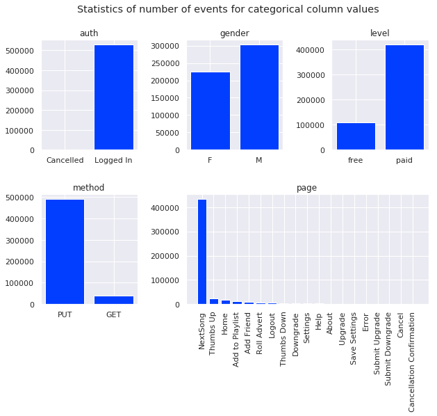

```python
# Getting a quick overview

# plot bar charts with number of events with respect to categorical values

cat_columns = ['auth', 'gender', 'level', 'method']

fig = plt.figure(figsize=(10, 7))
st = fig.suptitle("Statistics of number of events for categorical column values", fontsize="x-large")

grid = plt.GridSpec(2, 3, hspace=0.4, wspace=0.5)

counter = 0
for cat_column in cat_columns:

    value_counts = df.groupBy(cat_column).count().toPandas()

    trace_x = counter // 3
    trace_y = counter % 3

    x_pos = np.arange(0, len(value_counts))

    hist_ax = fig.add_subplot(grid[trace_x, trace_y])

    hist_ax.bar(x_pos, value_counts['count'].values, tick_label = value_counts[cat_column].values)

    hist_ax.set_title(cat_column)

    counter += 1

page_ax = fig.add_subplot(grid[1 , 1:])

value_counts = df.groupBy('page').count().orderBy('count', ascending=False).toPandas()

x_pos = np.arange(0, len(value_counts))

page_ax.bar(x_pos, value_counts['count'].values, tick_label = value_counts['page'].values)

page_ax.set_title('page')

for tick in page_ax.get_xticklabels():
    tick.set_rotation(90)

plt.show()
```

## Define Churn:

```python
# Churn is a label for user who has cancelled

# Define a flag function
flag_cancelation_event = udf(lambda x: 1 if x == "Cancellation Confirmation" else 0, IntegerType())

# apply to the dataframe
df = df.withColumn("churn", flag_cancelation_event("page"))

#Define window bounds
windowval = Window.partitionBy("userId").rangeBetween(Window.unboundedPreceding, Window.unboundedFollowing)

# Applying the window
df = df.withColumn("churn", Fsum("churn").over(windowval))
```

```python
# Again define pandas df for better view
df_p = df.toPandas()
```

```python
df_p.sample(10)
```

|  | artist | auth | firstName | gender | itemInSession | lastName | length | level | location | method | page | registration | sessionId | song | status | ts | userAgent | userId | churn |
| --- | --- | --- | --- | --- | --- | --- | --- | --- | --- | --- | --- | --- | --- | --- | --- | --- | --- | --- | --- |
| 359850 | Jennifer Lopez | Logged In | Deegan | M | 27 | Robinson | 245.96853 | paid | Hartford-West Hartford-East Hartford, CT | PUT | NextSong | 1529252604000 | 3066 | Waiting For Tonight | 200 | 1541462720000 | Mozilla/5.0 (Macintosh; Intel Mac OS X 10.9; r... | 33 | 0 |
| 59226 | Smash Mouth | Logged In | Colin | M | 130 | Freeman | 216.39791 | paid | Bakersfield, CA | PUT | NextSong | 1538173362000 | 4299 | All Star | 200 | 1543246143000 | Mozilla/5.0 (Windows NT 6.1; WOW64; rv:31.0) G... | 30 | 0 |
| 512410 | Linkin Park | Logged In | Natalee | F | 10 | Charles | 216.92036 | paid | Raleigh, NC | PUT | NextSong | 1536799770000 | 1074 | In The End (Album Version) | 200 | 1539449330000 | "Mozilla/5.0 (Windows NT 6.1; WOW64) AppleWebK... | 2 | 0 |
| 388019 | Florence + The Machine | Logged In | Brooklyn | F | 1 | Cisneros | 219.66322 | paid | Lafayette, LA | PUT | NextSong | 1538333222000 | 4774 | Dog Days Are Over (Radio Edit) | 200 | 1543613574000 | Mozilla/5.0 (Macintosh; Intel Mac OS X 10.9; r... | 209 | 0 |
| 107509 | None | Logged In | Bryson | M | 48 | Watson | NaN | paid | Charlotte-Concord-Gastonia, NC-SC | PUT | Thumbs Up | 1535400650000 | 816 | None | 307 | 1543337741000 | "Mozilla/5.0 (X11; Linux x86_64) AppleWebKit/5... | 300013 | 0 |
| 83086 | Chingy Featuring Fatman Scoop | Logged In | Mahi | F | 91 | Robinson | 228.07465 | paid | Houston-The Woodlands-Sugar Land, TX | PUT | NextSong | 1537898335000 | 258 | Let's Ride (Explicit) (Feat. Fatman Scoop) | 200 | 1540257869000 | Mozilla/5.0 (Macintosh; Intel Mac OS X 10.9; r... | 100022 | 0 |
| 439768 | None | Logged In | Carly | F | 130 | Weiss | NaN | paid | Minneapolis-St. Paul-Bloomington, MN-WI | PUT | Thumbs Down | 1533908361000 | 2895 | None | 307 | 1541568139000 | "Mozilla/5.0 (Windows NT 6.1; WOW64) AppleWebK... | 36 | 0 |
| 35366 | Christina Milian | Logged In | Jada | F | 93 | Barnes | 196.54485 | paid | Milwaukee-Waukesha-West Allis, WI | PUT | NextSong | 1536824159000 | 3840 | Dip It Low | 200 | 1542708694000 | "Mozilla/5.0 (Windows NT 6.1; WOW64) AppleWebK... | 69 | 0 |
| 335121 | Danzig | Logged In | Joseph | M | 91 | Morales | 260.51873 | paid | Corpus Christi, TX | PUT | NextSong | 1532063507000 | 899 | Sistinas | 200 | 1538741170000 | "Mozilla/5.0 (Macintosh; Intel Mac OS X 10_9_4... | 293 | 1 |
| 455583 | Ozzy Osbourne | Logged In | Robert | M | 96 | Henderson | 305.71057 | paid | Nashville-Davidson--Murfreesboro--Franklin, TN | PUT | NextSong | 1537543395000 | 2989 | Running Out Of Time | 200 | 1541375191000 | Mozilla/5.0 (Windows NT 6.1; WOW64; rv:31.0) G... | 253 | 0 |

```python
df_p.drop_duplicates(subset='userId').groupby(['churn'])['userId'].count()
```

```
churn
0    349
1     99
Name: userId, dtype: int64
```

```python
df.dropDuplicates(['userId']).groupby(['churn']).count().show()
```

```
+-----+-----+
|churn|count|
+-----+-----+
|    0|  349|
|    1|   99|
+-----+-----+
```

```python
# Exploring user status by gender
df.dropDuplicates(['userId', 'gender']).groupby(['churn', 'gender']).count().show()
```

```
+-----+------+-----+
|churn|gender|count|
+-----+------+-----+
|    0|     F|  153|
|    1|     M|   54|
|    1|     F|   45|
|    0|     M|  196|
+-----+------+-----+
```

```python
# Exploring user status by paid lever
df.dropDuplicates(['userId', 'level']).groupby(['churn', 'level']).count().show()
```

```
+-----+-----+-----+
|churn|level|count|
+-----+-----+-----+
|    1| paid|   75|
|    1| free|   82|
|    0| free|  288|
|    0| paid|  246|
+-----+-----+-----+
```

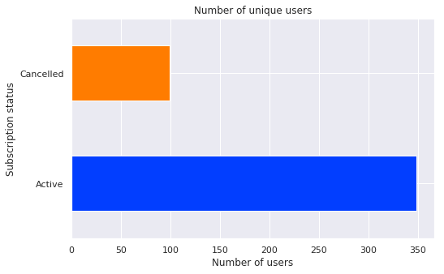

```python
def plot_frequency(subset, group, labels, x_title="Number of users", y_title="Subscription status"):
    ax = df_p.drop_duplicates(subset=subset).groupby(
                                group)['userId'].count().plot(
                                kind='barh', figsize=(8,5),
                                title='Number of unique users');
    ax.set_xlabel(x_title);
    ax.set_yticklabels(labels, rotation=0)
    ax.set_ylabel(y_title);

# Test
plot_frequency(['userId'], ['churn'], ['Active', 'Cancelled'])
```

Fortunatly for this theorestical company churn is a small percentage of their user base. Unsuprisingly, for us thus means we have to account for class imbalance when modeling.

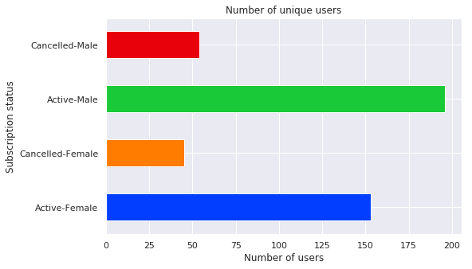

```python
plot_frequency(['userId', 'gender'],
               ['gender', 'churn'],
               ['Active-Female', 'Cancelled-Female', 'Active-Male', 'Cancelled-Male'])
```

Proportionaly at the macro level there seems to be little difference based on gender.

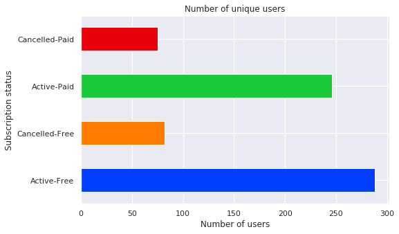

```python
plot_frequency(['userId', 'level'],
               ['level', 'churn'],
               ['Active-Free', 'Cancelled-Free', 'Active-Paid', 'Cancelled-Paid'])
```

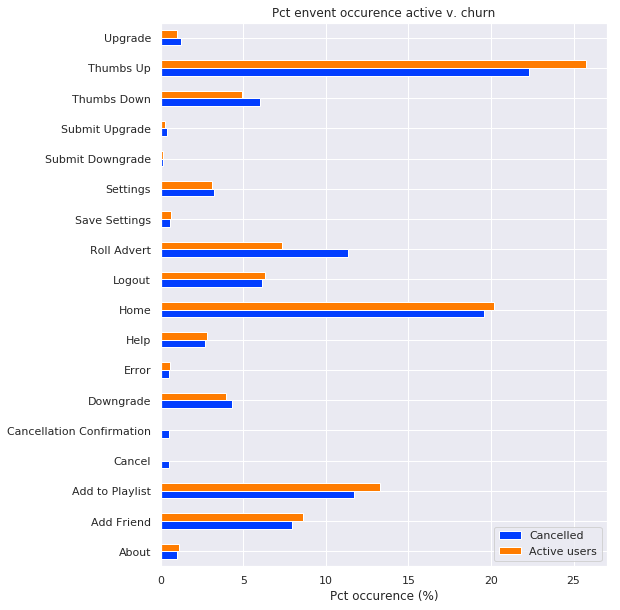

```python
users_1 = df_p[df_p.churn == 1].groupby(['page'])['userId'].count().drop('NextSong')
users_1 = users_1 /users_1.sum()*100

users_0 = df_p[df_p.churn == 0].groupby(['page'])['userId'].count().drop('NextSong')
users_0 = users_0 /users_0.sum()*100

df_users = pd.DataFrame({'Cancelled': users_1,'Active users':users_0})

ax = df_users.plot(kind='barh', figsize=(8,10));
ax.set_xlabel('Pct occurence (%)')
ax.set_title('Pct envent occurence active v. churn');
```

### Time Series

```python
# Definig user functions to get hour, day, month, and weekday of cancellation

get_hour = udf(lambda x: datetime.datetime.fromtimestamp(x / 1000.0).hour)
get_day = udf(lambda x: datetime.datetime.fromtimestamp(x / 1000.0).day)
get_month = udf(lambda x: datetime.datetime.fromtimestamp(x / 1000.0).month)

get_weekday = udf(lambda x: datetime.datetime.fromtimestamp(x / 1000.0).strftime('%w'))
# a useful resoucrse https://stackoverflow.com/questions/38928919/how-to-get-the-weekday-from-day-of-month-using-pyspark
```

```python
# Adding columns to the dataframe
funcs = {'hour':get_hour, 'day':get_day, 'month':get_month, 'week_day':get_weekday}
for label, func in funcs.items():
    df = df.withColumn(label, func(df.ts))
    print(f'Column {label} added successfully.')
```

```
Column hour added successfully.
Column day added successfully.
Column month added successfully.
Column week_day added successfully.
```

```python
# to help in better plotting and visuals
df_p = df.toPandas()
df_p.sample(5)
```

|  | artist | auth | firstName | gender | itemInSession | lastName | length | level | location | method | ... | song | status | ts | userAgent | userId | churn | hour | day | month | week_day |
| --- | --- | --- | --- | --- | --- | --- | --- | --- | --- | --- | --- | --- | --- | --- | --- | --- | --- | --- | --- | --- | --- |
| 59548 | None | Logged In | Colin | M | 127 | Freeman | NaN | paid | Bakersfield, CA | GET | ... | None | 200 | 1543356095000 | Mozilla/5.0 (Windows NT 6.1; WOW64; rv:31.0) G... | 30 | 0 | 22 | 27 | 11 | 2 |
| 213675 | JoJo | Logged In | Ainsley | F | 39 | Farley | 211.69587 | paid | McAllen-Edinburg-Mission, TX | PUT | ... | Coming For You | 200 | 1540187686000 | "Mozilla/5.0 (Windows NT 6.1; WOW64) AppleWebK... | 78 | 0 | 5 | 22 | 10 | 1 |
| 183862 | None | Logged In | Daelin | M | 87 | Turner | NaN | paid | New York-Newark-Jersey City, NY-NJ-PA | PUT | ... | None | 307 | 1542417328000 | "Mozilla/5.0 (Windows NT 6.1; WOW64) AppleWebK... | 126 | 1 | 1 | 17 | 11 | 6 |
| 138491 | Diamanda Galas | Logged In | Sofia | F | 33 | Gordon | 391.26159 | paid | Rochester, MN | PUT | ... | See That My Grave Is Kept Clean (Live 2002) | 200 | 1538544224000 | "Mozilla/5.0 (Macintosh; Intel Mac OS X 10_9_4... | 163 | 0 | 5 | 3 | 10 | 3 |
| 414416 | Battles | Logged In | Reece | M | 10 | Moore | 318.22322 | free | Washington-Arlington-Alexandria, DC-VA-MD-WV | PUT | ... | Bad Trails | 200 | 1540354699000 | "Mozilla/5.0 (Windows NT 6.1; WOW64) AppleWebK... | 200001 | 0 | 4 | 24 | 10 | 3 |

5 rows × 23 columns

```python
def get_series(df, col, churn, normalize=False):
    '''
    Get a series either of churn users and existing users
    return a sorted pandas series
    '''
    ser1 = df[df.churn == churn].groupby([col])['userId'].count()
    try:
        ser1.index = ser1.index.astype(int)
    except:
        pass
    if normalize:
        ser1=ser1/ser1.sum()*100
    return ser1.sort_index()
```

```python
def plot_time(df, col, normalize=True, figsize=(16,4), title=None, label_rotation=0):
    '''
    Plot a bar chart of churned and existing users based on
         a specific column (hour, month, day, week_day)

    '''
    df_time = pd.DataFrame({'Cancelled': get_series(df, col, 1, normalize),
                            'Active':get_series(df, col, 0, normalize)})
    ax = df_time.plot(kind='bar', figsize=figsize);
    ax.set_ylabel('Pct of users')
    if title is None:
        title = col
    ax.set_ylabel(f'Pct of users')
    #print(ax.get_xticks())
    ax.set_xticklabels(ax.get_xticklabels(), rotation=label_rotation)
    ax.set_title(f'Pct of users had action per {title}')
    return ax
```

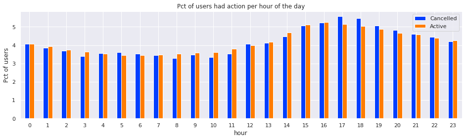

```python
plot_time(df_p, 'hour', title='hour of the day');
```

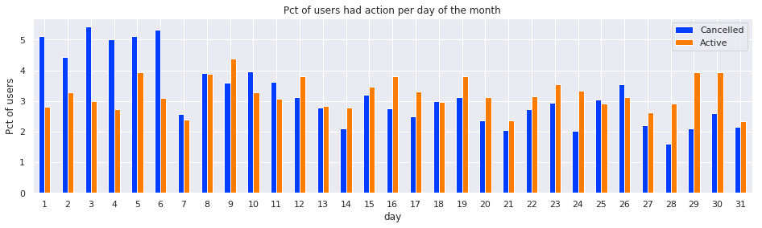

```python
plot_time(df_p, 'day', title='day of the month');
```

Churn seems to be much more likely at the begining of the month. When the service fee is charged?

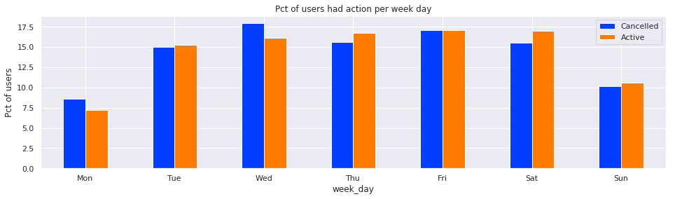

```python
ax = plot_time(df_p, 'week_day', title='week day')
ax.set_xticklabels(['Mon', 'Tue', 'Wed', 'Thu', 'Fri', 'Sat', 'Sun'], rotation=0);
```

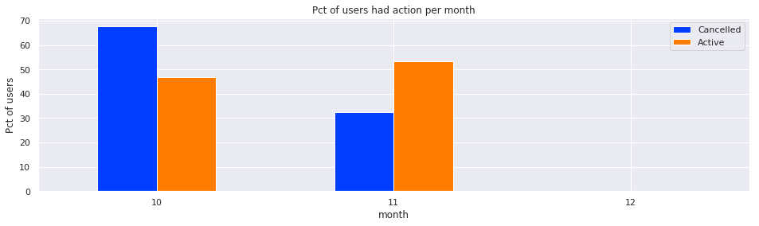

```python
plot_time(df_p, 'month');
```

### Operating System & Device

```python
df_p.userAgent.unique().shape[0]
```

```
71
```

As you can see there are many different `agents` and the data is somewhat messy so we need to clean it up some.

```python
agents = [x.strip() for x  in df_p.userAgent.unique()]
# see sample
[agents[x] for x in [0, 2, 4, 10]]
```

```
['"Mozilla/5.0 (iPhone; CPU iPhone OS 7_1_2 like Mac OS X) AppleWebKit/537.51.2 (KHTML, like Gecko) Version/7.0 Mobile/11D257 Safari/9537.53"',
 '"Mozilla/5.0 (Macintosh; Intel Mac OS X 10_9_4) AppleWebKit/537.78.2 (KHTML, like Gecko) Version/7.0.6 Safari/537.78.2"',
 '"Mozilla/5.0 (Macintosh; Intel Mac OS X 10_9_4) AppleWebKit/537.36 (KHTML, like Gecko) Chrome/36.0.1985.143 Safari/537.36"',
 '"Mozilla/5.0 (Macintosh; Intel Mac OS X 10_9_4) AppleWebKit/537.36 (KHTML, like Gecko) Chrome/37.0.2062.94 Safari/537.36"']
```

```python
# TO get the data between parenthesis
regex = '\(([^\)]*)\)'

# All OSs
sorted(list(set([re.findall(
    regex, x)[0].split(';')[0].capitalize(
) for x  in agents])))
```

```
['Compatible',
 'Ipad',
 'Iphone',
 'Macintosh',
 'Windows nt 5.1',
 'Windows nt 6.0',
 'Windows nt 6.1',
 'Windows nt 6.2',
 'Windows nt 6.3',
 'X11']
```

```python
# Create mappers for the os
map_macro = {'Compatible': 'Windows',  'Ipad': 'Mac',  'Iphone': 'Mac',
          'Macintosh': 'Mac',  'Windows nt 5.1': 'Windows',
          'Windows nt 6.0': 'Windows',  'Windows nt 6.1': 'Windows',
          'Windows nt 6.2': 'Windows',  'Windows nt 6.3': 'Windows',
          'X11': 'Linux'}
map_os = {'Compatible': 'Windows 7',  'Ipad': 'iPad',  'Iphone': 'iPhone',
          'Macintosh': 'MacOS',  'Windows nt 5.1': 'Windows XP',
          'Windows nt 6.0': 'Windows Vista',  'Windows nt 6.1': 'Windows 7',
          'Windows nt 6.2': 'Windows 8.0',  'Windows nt 6.3': 'Windows 8.1',
          'X11': 'Linux'}

print(sorted(list(set([map_macro[re.findall(regex, x)[0].split(';')[0].capitalize()] for x  in agents]))),
sorted(list(set([map_os[re.findall(regex, x)[0].split(';')[0].capitalize()] for x  in agents]))))
```

```
['Linux', 'Mac', 'Windows'] ['Linux', 'MacOS', 'Windows 7', 'Windows 8.0', 'Windows 8.1', 'Windows Vista', 'Windows XP', 'iPad', 'iPhone']
```

```python
# Define user defined functions
os_general = udf(lambda x: map_macro[re.findall(regex, x)[0].split(';')[0].capitalize()])
df = df.withColumn("os_general", os_general(df.userAgent))

os_specific = udf(lambda x: map_os[re.findall(regex, x)[0].split(';')[0].capitalize()])
df = df.withColumn("os_specific", os_specific(df.userAgent))
```

### User State

```python
df_p.location.unique().shape[0]
```

```
192
```

```python
states = set([state[1].strip() for state in [x.split(',') for x in df_p.location.unique()]])
len(states)
```

```
70
```

```python
# Define a user defined function
get_state = udf(lambda x: x.split(',')[1].strip())
df = df.withColumn("state", get_state(df.location))
```

```python
df.take(3)
```

```
[Row(artist='Darude', auth='Logged In', firstName='Darianna', gender='F', itemInSession=0, lastName='Carpenter', length=226.08934, level='free', location='Bridgeport-Stamford-Norwalk, CT', method='PUT', page='NextSong', registration=1538016340000, sessionId=62, song='Sandstorm', status=200, ts=15389…
 Row(artist='Justice', auth='Logged In', firstName='Darianna', gender='F', itemInSession=1, lastName='Carpenter', length=285.41342, level='free', location='Bridgeport-Stamford-Norwalk, CT', method='PUT', page='NextSong', registration=1538016340000, sessionId=62, song='Phantom Part 1.5 (Album Version…
 Row(artist='Five Iron Frenzy', auth='Logged In', firstName='Darianna', gender='F', itemInSession=2, lastName='Carpenter', length=236.09424, level='free', location='Bridgeport-Stamford-Norwalk, CT', method='PUT', page='NextSong', registration=1538016340000, sessionId=62, song='Canada', status=200, t…
```

```python
# Convert to pandas for better visuals
df_p = df.toPandas()
df_p.sample(5)
```

|  | artist | auth | firstName | gender | itemInSession | lastName | length | level | location | method | ... | userAgent | userId | churn | hour | day | month | week_day | os_general | os_specific | state |
| --- | --- | --- | --- | --- | --- | --- | --- | --- | --- | --- | --- | --- | --- | --- | --- | --- | --- | --- | --- | --- | --- |
| 278192 | None | Logged In | Camryn | F | 7 | Garcia | NaN | free | Grand Rapids-Wyoming, MI | PUT | ... | "Mozilla/5.0 (Macintosh; Intel Mac OS X 10_9_4... | 100042 | 1 | 14 | 18 | 10 | 4 | Mac | MacOS | MI |
| 339387 | The Police | Logged In | Joseph | M | 239 | Morales | 289.85424 | paid | Corpus Christi, TX | PUT | ... | "Mozilla/5.0 (Macintosh; Intel Mac OS X 10_9_4... | 293 | 1 | 11 | 16 | 11 | 5 | Mac | MacOS | TX |
| 170284 | Brother Beyond | Logged In | Harley | F | 200 | Taylor | 212.08771 | paid | Miami-Fort Lauderdale-West Palm Beach, FL | PUT | ... | "Mozilla/5.0 (Windows NT 6.3; WOW64) AppleWebK... | 300036 | 0 | 3 | 6 | 11 | 2 | Windows | Windows 8.1 | FL |
| 220889 | Aphex Twin | Logged In | Viviana | F | 556 | Finley | 290.97751 | paid | Gallup, NM | PUT | ... | "Mozilla/5.0 (Windows NT 6.2; WOW64) AppleWebK... | 198 | 1 | 13 | 10 | 10 | 3 | Windows | Windows 8.0 | NM |
| 218805 | Pearl Jam | Logged In | Autumn | F | 73 | Martin | 67.44771 | paid | Gainesville, FL | PUT | ... | "Mozilla/5.0 (Windows NT 6.1; WOW64) AppleWebK... | 77 | 0 | 18 | 2 | 10 | 2 | Windows | Windows 7 | FL |

5 rows × 26 columns

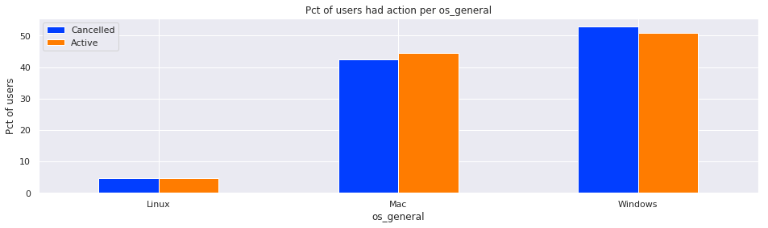

```python
plot_time(df_p, 'os_general');
```

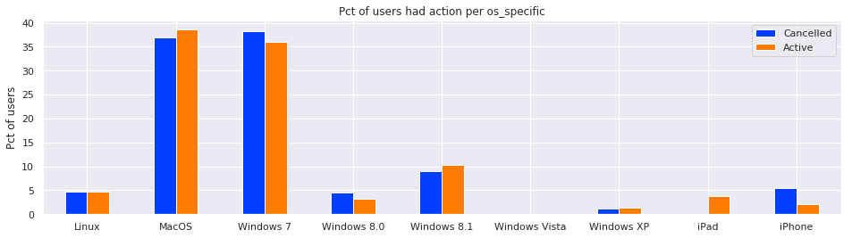

```python
plot_time(df_p, 'os_specific');
```

The operating system, even at a specific version level does not seem to have a pronounced effect on the chrun likelyhood.

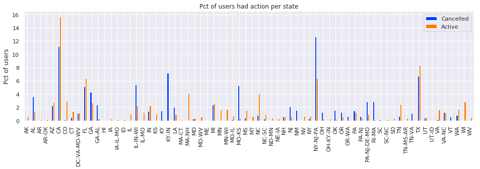

```python
plot_time(df_p, 'state', label_rotation=90);
```

It does seem that location a better feature as some of the states seem to have a much highr churn percentage than others.

# Feature Engineering

Once you've familiarized yourself with the data, build out the features you find promising to train your model on. To work with the full dataset, you can follow the following steps.

- Write a script to extract the necessary features from the smaller subset of data
- Ensure that your script is scalable, using the best practices discussed in Lesson 3
- Try your script on the full data set, debugging your script if necessary

If you are working in the classroom workspace, you can just extract features based on the small subset of data contained here. Be sure to transfer over this work to the larger dataset when you work on your Spark cluster.

```python
churn_users = df.select('userId', 'churn').dropDuplicates()

# check
churn_users.show(5)
```

```
+------+-----+
|userId|churn|
+------+-----+
|100010|    1|
|200002|    1|
|   296|    1|
|   125|    0|
|   124|    1|
+------+-----+
only showing top 5 rows
```

```python
# Converting Gender
def create_dummy_df (col, dictionary):
    '''
    Create a dataframe to map a variable
    col: the column name
    dictionary: the mapping of from->to numeric values
    return a dataframe of 2 columns
    '''
    # To map M and F to numeric values, we first should map to string numbers (to avoid spark error)
    col_df = df.select('userId', col).dropDuplicates().replace(dictionary, subset=col)
    # Then convert the result to numeric value
    col_df = col_df.select('userId', col_df[col].cast('int'))
    # Check
    print(col_df.printSchema(), col_df.show(3))
    return col_df

gender_df = create_dummy_df('gender', {'M':'1', 'F':'0'})
```

```
root
 |-- userId: string (nullable = true)
 |-- gender: integer (nullable = true)

+------+------+
|userId|gender|
+------+------+
|   234|     1|
|   188|     0|
|    44|     0|
+------+------+
only showing top 3 rows

None None
```

```python
# Generating dummy vars for the OS
os_titles =  df.select('os_specific').distinct().rdd.flatMap(lambda x: x).collect()
os_expr = [sF.when(sF.col('os_specific') == osdt, 1).otherwise(0).alias("OS_" + osdt) for osdt in os_titles]
os_df = df.select('userId', *os_expr)
os_df.show(10)
```

```
+------+-------+--------------+---------+--------+----------------+--------------+--------+-------------+------------+
|userId|OS_iPad|OS_Windows 8.1|OS_iPhone|OS_Linux|OS_Windows Vista|OS_Windows 8.0|OS_MacOS|OS_Windows XP|OS_Windows 7|
+------+-------+--------------+---------+--------+----------------+--------------+--------+-------------+------------+
|   293|      0|             0|        0|       0|               0|             0|       1|            0|           0|
|    98|      0|             0|        0|       0|               0|             0|       1|            0|           0|
|   179|      0|             0|        0|       0|               0|             0|       1|            0|           0|
|   179|      0|             0|        0|       0|               0|             0|       1|            0|           0|
|   246|      0|             0|        0|       0|               0|             0|       0|            0|           1|
|   163|      0|             0|        0|       0|               0|             0|       1|            0|           0|
|   179|      0|             0|        0|       0|               0|             0|       1|            0|           0|
|   175|      0|             0|        0|       0|               0|             0|       1|            0|           0|
|   100|      0|             0|        0|       0|               0|             0|       0|            0|           1|
|   100|      0|             0|        0|       0|               0|             0|       0|            0|           1|
+------+-------+--------------+---------+--------+----------------+--------------+--------+-------------+------------+
only showing top 10 rows
```

```python
os_df.printSchema()
```

```
root
 |-- userId: string (nullable = true)
 |-- OS_iPad: integer (nullable = false)
 |-- OS_Windows 8.1: integer (nullable = false)
 |-- OS_iPhone: integer (nullable = false)
 |-- OS_Linux: integer (nullable = false)
 |-- OS_Windows Vista: integer (nullable = false)
 |-- OS_Windows 8.0: integer (nullable = false)
 |-- OS_MacOS: integer (nullable = false)
 |-- OS_Windows XP: integer (nullable = false)
 |-- OS_Windows 7: integer (nullable = false)
```

```python
level_df = create_dummy_df('level', {'paid':'1', 'free':'0'})
```

```
root
 |-- userId: string (nullable = true)
 |-- level: integer (nullable = true)

+------+-----+
|userId|level|
+------+-----+
|    94|    1|
|100021|    0|
|100029|    0|
+------+-----+
only showing top 3 rows

None None
```

```python
# Number of artists in the dataset
df_p.artist.unique().shape[0]
```

```
21248
```

```python
song_length = df.filter(df.page=='NextSong').select('userId', 'sessionId', 'length')
song_length = song_length.withColumn('hours', (song_length.length / 3600))
song_length = song_length.groupBy('userId', 'sessionId').sum('hours')
song_length = song_length.groupBy('userId').agg(
                        sF.avg('sum(hours)').alias('mean_hours'),
                        sF.stddev('sum(hours)').alias('stdev_hours')).na.fill(0)
song_length.toPandas().head(10)
```

|  | userId | mean_hours | stdev_hours |
| --- | --- | --- | --- |
| 0 | 200002 | 4.371990 | 2.886952 |
| 1 | 296 | 1.573008 | 1.357670 |
| 2 | 100010 | 3.593188 | 0.309570 |
| 3 | 125 | 1.464238 | 1.890002 |
| 4 | 7 | 2.147908 | 2.039100 |
| 5 | 124 | 7.928195 | 7.686869 |
| 6 | 51 | 3.712067 | 4.123469 |
| 7 | 200037 | 1.195097 | 1.036558 |
| 8 | 205 | 14.647268 | 11.221074 |
| 9 | 169 | 0.973383 | 0.631214 |

```python
# To get the Number of ThumbsUp, ThumbsDown, InviteFriends, downgrades, ...
# I think it is better to get all actions except Chorn actions (Cancel, cancelation confirmation)
# The to normalize them as percent to sum all to 100.

# The distribution of pages per user (FILLING NAN with 0)
user_page_distribution = df.groupby('userId').pivot('page').count().na.fill(0) #.toPandas().head(30)

# Drop Cancel	Cancellation Confirmation columns
user_page_distribution = user_page_distribution.drop(*['Cancel','Cancellation Confirmation'])

# Normalizing each row to sum to 1

# SOURCES
# https://stackoverflow.com/questions/47641076/spark-normalize-each-row-of-a-dataframe
# https://stackoverflow.com/questions/31955309/add-column-sum-as-new-column-in-pyspark-dataframe

# the columns to be summed
pages_cols = user_page_distribution.columns[1:]

# Add a total column
new_df = user_page_distribution.withColumn('total', sum(user_page_distribution[col] for col in pages_cols))

# Apply normalization per column
for col in pages_cols:
    new_df = new_df.withColumn(f'norm_{col}', new_df[col] / new_df['total'] * 100.)

# Remove the total column
new_df = new_df.drop('total')

# Remove the original columns
new_df = new_df.drop(*pages_cols)

# Rename the normalized columns back
oldColumns = new_df.columns
newColumns = ['userId'] + pages_cols
user_page_distribution = reduce(lambda new_df, idx: new_df.withColumnRenamed(oldColumns[idx], newColumns[idx]), range(len(oldColumns)), new_df)

# Freeup memory
new_df=None

user_page_distribution.toPandas().head(10)
```

|  | userId | About | Add Friend | Add to Playlist | Downgrade | Error | Help | Home | Logout | NextSong | Roll Advert | Save Settings | Settings | Submit Downgrade | Submit Upgrade | Thumbs Down | Thumbs Up | Upgrade |
| --- | --- | --- | --- | --- | --- | --- | --- | --- | --- | --- | --- | --- | --- | --- | --- | --- | --- | --- |
| 0 | 200002 | 0.254453 | 0.508906 | 1.526718 | 0.763359 | 0.000000 | 0.254453 | 5.852417 | 2.798982 | 78.880407 | 2.798982 | 0.000000 | 0.508906 | 0.0 | 0.254453 | 1.272265 | 3.816794 | 0.508906 |
| 1 | 100010 | 0.000000 | 2.222222 | 0.740741 | 0.000000 | 0.000000 | 0.000000 | 2.222222 | 0.740741 | 71.111111 | 16.296296 | 0.000000 | 0.000000 | 0.0 | 0.000000 | 2.222222 | 2.962963 | 1.481481 |
| 2 | 296 | 0.000000 | 1.333333 | 2.000000 | 0.666667 | 0.000000 | 1.333333 | 4.666667 | 2.000000 | 74.666667 | 6.000000 | 0.000000 | 0.666667 | 0.0 | 0.666667 | 0.000000 | 5.333333 | 0.666667 |
| 3 | 125 | 0.000000 | 3.571429 | 2.380952 | 0.000000 | 0.000000 | 2.380952 | 2.380952 | 0.000000 | 73.809524 | 7.142857 | 0.000000 | 3.571429 | 0.0 | 0.000000 | 1.190476 | 3.571429 | 0.000000 |
| 4 | 51 | 0.000000 | 0.920245 | 2.453988 | 1.226994 | 0.613497 | 0.000000 | 5.214724 | 1.840491 | 81.595092 | 0.306748 | 0.000000 | 0.613497 | 0.0 | 0.000000 | 0.306748 | 4.907975 | 0.000000 |
| 5 | 124 | 0.139276 | 1.207057 | 2.089136 | 0.974930 | 0.000000 | 0.464253 | 3.249768 | 0.789229 | 84.772516 | 0.046425 | 0.139276 | 0.696379 | 0.0 | 0.000000 | 0.696379 | 4.735376 | 0.000000 |
| 6 | 7 | 0.333333 | 2.666667 | 1.000000 | 0.000000 | 0.000000 | 0.500000 | 6.000000 | 1.833333 | 77.000000 | 5.833333 | 0.333333 | 0.833333 | 0.0 | 0.000000 | 0.666667 | 2.000000 | 1.000000 |
| 7 | 200037 | 0.653595 | 1.307190 | 2.614379 | 0.000000 | 0.000000 | 0.000000 | 3.921569 | 0.000000 | 79.738562 | 5.882353 | 0.000000 | 0.653595 | 0.0 | 0.000000 | 1.960784 | 3.267974 | 0.000000 |
| 8 | 169 | 0.000000 | 4.026846 | 0.000000 | 0.000000 | 0.000000 | 0.000000 | 4.026846 | 0.000000 | 75.167785 | 8.724832 | 0.671141 | 2.013423 | 0.0 | 0.000000 | 0.000000 | 4.026846 | 1.342282 |
| 9 | 205 | 0.241158 | 1.688103 | 2.009646 | 0.803859 | 0.080386 | 0.884244 | 3.456592 | 1.366559 | 84.244373 | 0.000000 | 0.160772 | 0.241158 | 0.0 | 0.000000 | 0.803859 | 4.019293 | 0.000000 |

```python
# 2-F Number of songs per session

# number of changing songs
song_user_df = df.filter(df.page == 'NextSong').groupBy(
                        'userId', 'sessionId').count()
song_user_df = song_user_df.groupBy('userId').agg(
                        sF.avg('count').alias('mean_songs'),
                        sF.stddev('count').alias('stdev_songs'))
song_user_df = song_user_df.na.fill(0)
song_user_df.show(3)
```

```
+------+----------+------------------+
|userId|mean_songs|       stdev_songs|
+------+----------+------------------+
|200002|      62.0|38.255718526777144|
|   296|      22.4|  19.3597520645281|
|100010|      48.0|1.4142135623730951|
+------+----------+------------------+
only showing top 3 rows
```

```python
# Number of artists the user fans
artists_user_fans = df.select('userId', 'artist').dropDuplicates().groupBy('userId').count().withColumnRenamed("count", "num_aritst")
artists_user_fans.show(3)
```

```
+------+----------+
|userId|num_aritst|
+------+----------+
|   296|       109|
|100010|        95|
|200002|       288|
+------+----------+
only showing top 3 rows
```

```python
# 2-G.1 Session Duration

session_end = df.groupBy('userId', 'sessionId').max('ts').withColumnRenamed(
                                                            'max(ts)', 'end')
session_start = df.groupBy('userId', 'sessionId').min('ts').withColumnRenamed(
                                                            'min(ts)', 'start')
session_df = session_start.join(session_end,['userId', 'sessionId'])
ticks_per_hours = 1000 * 60 * 60
session_df = session_df.select('userId', 'sessionId', ((
    session_df.end-session_df.start)/ticks_per_hours).alias('session_hours'))
session_df.show(3)
```

```
+------+---------+------------------+
|userId|sessionId|     session_hours|
+------+---------+------------------+
|100002|      293| 5.557222222222222|
|100025|      287| 5.882777777777778|
|100028|       28|1.1288888888888888|
+------+---------+------------------+
only showing top 3 rows
```

```python
# 2-G.2  Get Average, and Standard deviation of the session duration per user

session_user_df = session_df.groupBy('userId').agg(
                        sF.avg('session_hours').alias('mean_session_h'),
                        sF.stddev('session_hours').alias('stdev_session_h'))
# Fill NaN with 0
session_user_df = session_user_df.na.fill(0)
session_user_df.show(3)
```

```
+------+------------------+------------------+
|userId|    mean_session_h|   stdev_session_h|
+------+------------------+------------------+
|200002| 4.384333333333333|2.9375948802643896|
|   296|1.6172777777777774|1.4737091207327393|
|100010|3.5062499999999996|0.2873603391321997|
+------+------------------+------------------+
only showing top 3 rows
```

```python
# 2-H Sessions count per user
num_sessions_user_df = df.select('userId', 'sessionId').dropDuplicates().groupby('userId').count().withColumnRenamed('count', 'num_sessions')
num_sessions_user_df.show(3)
```

```
+------+------------+
|userId|num_sessions|
+------+------------+
|200002|           5|
|   296|           5|
|100010|           2|
+------+------------+
only showing top 3 rows
```

```python
# 2-I The user's subscription age
def days_since_subscription(df, col_name='days_on'):
    # timestamp of users registration
    reg_ts = df.select('userId', 'registration').dropDuplicates().withColumnRenamed('registration', 'start')
    # reg_ts.show(5)
    # The maximum timestamp found for the user
    end_ts = df.groupBy('userId').max('ts').withColumnRenamed('max(ts)', 'end')
    # end_ts.show(5)
    # The difference
    reg_df = reg_ts.join(end_ts,'userId')
    ticks_per_day = 1000 * 60 * 60 * 24 # as the timestamp is in ticks (0.001 seconds)
    # Merge in one df
    reg_df = reg_df.select('userId', ((reg_df.end-reg_df.start)/ticks_per_day).alias(col_name))
    # reg_ts.join(user_max_ts, user_reg_ts.userId == user_max_ts.userId).select(user_reg_ts["userId"], ((user_max_ts["max(ts)"]-user_reg_ts["registration"])/(1000*60*60*24)).alias("regDay"))
    return reg_df

reg_df = days_since_subscription(df, col_name='days_total_subscription')
reg_df.show(5)
```

```
+------+-----------------------+
|userId|days_total_subscription|
+------+-----------------------+
|100010|     14.328449074074074|
|200002|      53.32314814814815|
|   296|      26.63826388888889|
|   125|     105.42211805555556|
|   124|      112.5537962962963|
+------+-----------------------+
only showing top 5 rows
```

```python
df_paid = df.filter(df.level=='paid')
paid_df = days_since_subscription(df_paid, col_name='days_paid_subscription')
paid_df.show(5)
```

```
+------+----------------------+
|userId|days_paid_subscription|
+------+----------------------+
|200002|     53.32314814814815|
|   296|     26.63826388888889|
|   124|     112.5537962962963|
|    51|     18.84582175925926|
|   205|    52.055104166666666|
+------+----------------------+
only showing top 5 rows
```

```python
df_free = df.filter(df.level=='free')
free_df = days_since_subscription(df_free, col_name='days_free_subscription')
free_df.show(5)
```

```
+------+----------------------+
|userId|days_free_subscription|
+------+----------------------+
|100010|    14.328449074074074|
|200002|     35.79487268518518|
|   296|    20.554502314814815|
|   125|    105.42211805555556|
|     7|     78.02979166666667|
+------+----------------------+
only showing top 5 rows
```

```python
paid_free_df = df.filter(df.page=='NextSong').groupBy('userId').pivot('level').count()
paid_free_df = paid_free_df.na.fill(0)
active_cols = paid_free_df.columns[1:]
paid_free_df = paid_free_df.withColumn('total',
                                       sum(paid_free_df[col] for col in active_cols))
for col in active_cols:
    paid_free_df = paid_free_df.withColumn(f'{col}_percent',
                                           paid_free_df[col] / paid_free_df.total * 100)
active_cols.append('total')
paid_free_df = paid_free_df.drop(*active_cols)
paid_free_df.show(10)
```

```
+------+-----------------+------------------+
|userId|     free_percent|      paid_percent|
+------+-----------------+------------------+
|200002|53.87096774193548| 46.12903225806452|
|   296|67.85714285714286|32.142857142857146|
|100010|            100.0|               0.0|
|   125|            100.0|               0.0|
|     7|            100.0|               0.0|
|   124|              0.0|             100.0|
|    51|              0.0|             100.0|
|200037|            100.0|               0.0|
|   205|              0.0|             100.0|
|   169|            100.0|               0.0|
+------+-----------------+------------------+
only showing top 10 rows
```

```python
paid_free_df = paid_free_df.drop('free_percent')
paid_free_df.show(3)
```

```
+------+------------------+
|userId|      paid_percent|
+------+------------------+
|200002| 46.12903225806452|
|   296|32.142857142857146|
|100010|               0.0|
+------+------------------+
only showing top 3 rows
```

```python
# bring it all together
user_features = [gender_df,
                 os_df,
                 paid_free_df,
                 song_length,
                 user_page_distribution,
                 song_user_df,
                 artists_user_fans,
                 session_user_df,
                 num_sessions_user_df,
                 reg_df]


user_features_names = ['gender_df',
                       'os_df',
                       'paid_free_df',
                       'song_length',
                       'user_page_distribution',
                       'song_user_df',
                       'artists_user_fans',
                       'session_user_df',
                       'num_sessions_user_df',
                       'reg_df'
                      ]
```

```python
# Initialize the final_df
churn_users = df.select('userId', 'churn').dropDuplicates()
final_df = churn_users

def join_features(base, new):
    df_to_join = new #.withColumnRenamed('userId', 't_userId')
    base = base.join(df_to_join, 'userId', how='inner') #.drop('t_userId')#.show(10)
    return base.dropDuplicates()

for i, feature in enumerate(user_features):
    print(f'Preparing features of the {user_features_names[i]} dataframe', end='; ')
    final_df = join_features(final_df, feature)
    print (f"the new dimensions: {final_df.count()} * {len(final_df.columns)}")
final_df = final_df.orderBy('userId', ascending=True)
print('##### COMPLETE #####')
```

```
Preparing features of the gender_df dataframe; the new dimensions: 448 * 3
Preparing features of the os_df dataframe; the new dimensions: 448 * 12
Preparing features of the paid_free_df dataframe; the new dimensions: 448 * 13
Preparing features of the song_length dataframe; the new dimensions: 448 * 15
Preparing features of the user_page_distribution dataframe; the new dimensions: 448 * 32
Preparing features of the song_user_df dataframe; the new dimensions: 448 * 34
Preparing features of the artists_user_fans dataframe; the new dimensions: 448 * 35
Preparing features of the session_user_df dataframe; the new dimensions: 448 * 37
Preparing features of the num_sessions_user_df dataframe; the new dimensions: 448 * 38
Preparing features of the reg_df dataframe; the new dimensions: 448 * 39
##### COMPLETE #####
```

#### Save Data For Modeling

```python
# Saving as SPARK format
final_df.write.save('saved_user_dataset.CSV', format='csv', header=True)
```

```python
final_df_p = final_df.toPandas()
final_df_p.head(10)
```

|  | userId | churn | gender | OS_iPad | OS_Windows 8.1 | OS_iPhone | OS_Linux | OS_Windows Vista | OS_Windows 8.0 | OS_MacOS | ... | Thumbs Down | Thumbs Up | Upgrade | mean_songs | stdev_songs | num_aritst | mean_session_h | stdev_session_h | num_sessions | days_total_subscription |
| --- | --- | --- | --- | --- | --- | --- | --- | --- | --- | --- | --- | --- | --- | --- | --- | --- | --- | --- | --- | --- | --- |
| 0 | 10 | 1 | 1 | 0 | 0 | 0 | 0 | 0 | 0 | 1 | ... | 0.237530 | 4.038005 | 0.000000 | 360.000000 | 0.000000 | 307 | 25.040000 | 0.000000 | 1 | 10.368854 |
| 1 | 100 | 0 | 1 | 0 | 0 | 0 | 0 | 0 | 0 | 0 | ... | 0.925231 | 3.575894 | 0.025006 | 86.717949 | 91.946480 | 1964 | 5.841296 | 6.280176 | 39 | 65.095058 |
| 2 | 100001 | 1 | 0 | 0 | 0 | 0 | 0 | 0 | 0 | 1 | ... | 0.757576 | 3.787879 | 1.515152 | 32.000000 | 19.467922 | 94 | 2.294352 | 1.406664 | 3 | 44.726771 |
| 3 | 100002 | 0 | 0 | 0 | 0 | 0 | 0 | 0 | 0 | 0 | ... | 1.129944 | 4.519774 | 0.564972 | 34.250000 | 26.663021 | 129 | 2.504375 | 2.083174 | 4 | 129.768183 |
| 4 | 100003 | 1 | 0 | 0 | 0 | 0 | 0 | 0 | 0 | 0 | ... | 1.212121 | 1.939394 | 0.242424 | 82.625000 | 101.123598 | 546 | 4.948796 | 6.582846 | 9 | 50.373241 |
| 5 | 100004 | 1 | 0 | 0 | 0 | 0 | 0 | 0 | 0 | 0 | ... | 0.539084 | 4.043127 | 0.539084 | 52.400000 | 38.636770 | 243 | 3.701611 | 2.780477 | 5 | 126.756227 |
| 6 | 100005 | 1 | 1 | 0 | 0 | 0 | 0 | 0 | 0 | 1 | ... | 1.020408 | 2.040816 | 1.020408 | 36.000000 | 29.698485 | 70 | 2.317222 | 1.995220 | 2 | 71.872141 |
| 7 | 100006 | 0 | 0 | 0 | 1 | 0 | 0 | 0 | 0 | 0 | ... | 0.800000 | 3.733333 | 0.266667 | 73.750000 | 35.226647 | 262 | 3.932944 | 2.917320 | 5 | 65.484688 |
| 8 | 100007 | 0 | 0 | 0 | 1 | 0 | 0 | 0 | 0 | 0 | ... | 0.570342 | 3.802281 | 0.190114 | 71.083333 | 50.978531 | 681 | 4.815023 | 3.462099 | 12 | 115.284757 |
| 9 | 100008 | 0 | 0 | 0 | 0 | 0 | 0 | 0 | 0 | 1 | ... | 1.079914 | 4.103672 | 0.000000 | 64.333333 | 21.602469 | 337 | 4.371574 | 1.602878 | 6 | 71.552477 |

10 rows × 39 columns

```python
final_df_p.to_csv('saved_user_dataset_pd.CSV', index=False)
```

# Modeling

Split the full dataset into train, test, and validation sets. Test out several of the machine learning methods you learned. Evaluate the accuracy of the various models, tuning parameters as necessary. Determine your winning model based on test accuracy and report results on the validation set. Since the churned users are a fairly small subset, I suggest using F1 score as the metric to optimize.

```python
final_df = spark.read.csv('saved_user_dataset.CSV', header = True)
pfinal_df = final_df.toPandas()
pfinal_df.head()
```

|  | userId | churn | gender | OS_iPad | OS_Windows 8.1 | OS_iPhone | OS_Linux | OS_Windows Vista | OS_Windows 8.0 | OS_MacOS | ... | Thumbs Down | Thumbs Up | Upgrade | mean_songs | stdev_songs | num_aritst | mean_session_h | stdev_session_h | num_sessions | days_total_subscription |
| --- | --- | --- | --- | --- | --- | --- | --- | --- | --- | --- | --- | --- | --- | --- | --- | --- | --- | --- | --- | --- | --- |
| 0 | 200023 | 1 | 0 | 0 | 1 | 0 | 0 | 0 | 0 | 0 | ... | 2.505926176769387 | 4.063664070436844 | 0.5418218760582458 | 38.706896551724135 | 40.53155955578564 | 1451 | 2.7516807909604526 | 2.966392909212397 | 59 | 50.84766203703704 |
| 1 | 200024 | 1 | 1 | 0 | 0 | 0 | 1 | 0 | 0 | 0 | ... | 2.928870292887029 | 4.435146443514645 | 0.08368200836820083 | 87.27272727272727 | 116.12673327799324 | 746 | 5.564236111111111 | 7.999844250136687 | 12 | 49.70068287037037 |
| 2 | 200025 | 0 | 1 | 0 | 0 | 0 | 0 | 0 | 0 | 0 | ... | 2.1739130434782608 | 3.059581320450886 | 0.322061191626409 | 65.6 | 63.40099142983266 | 761 | 4.409777777777777 | 4.228853590726326 | 15 | 122.39989583333333 |
| 3 | 29 | 0 | 1 | 0 | 0 | 0 | 0 | 0 | 0 | 1 | ... | 0.723404255319149 | 3.829787234042553 | 0.1702127659574468 | 48.8974358974359 | 46.042768945836976 | 1232 | 3.3098931623931627 | 3.2484525284602235 | 39 | 75.79474537037036 |
| 4 | 290 | 0 | 1 | 0 | 1 | 0 | 0 | 0 | 0 | 0 | ... | 0.7874015748031495 | 5.511811023622047 | 0.26246719160104987 | 66.77777777777777 | 45.45541160790918 | 507 | 4.641141975308641 | 3.0925344739077616 | 9 | 91.12621527777777 |

5 rows × 39 columns

```python
final_df.printSchema()
```

```
root
 |-- userId: string (nullable = true)
 |-- churn: string (nullable = true)
 |-- gender: string (nullable = true)
 |-- OS_iPad: string (nullable = true)
 |-- OS_Windows 8.1: string (nullable = true)
 |-- OS_iPhone: string (nullable = true)
 |-- OS_Linux: string (nullable = true)
 |-- OS_Windows Vista: string (nullable = true)
 |-- OS_Windows 8.0: string (nullable = true)
 |-- OS_MacOS: string (nullable = true)
 |-- OS_Windows XP: string (nullable = true)
 |-- OS_Windows 7: string (nullable = true)
 |-- paid_percent: string (nullable = true)
 |-- mean_hours: string (nullable = true)
 |-- stdev_hours: string (nullable = true)
 |-- About: string (nullable = true)
 |-- Add Friend: string (nullable = true)
 |-- Add to Playlist: string (nullable = true)
 |-- Downgrade: string (nullable = true)
 |-- Error: string (nullable = true)
 |-- Help: string (nullable = true)
 |-- Home: string (nullable = true)
 |-- Logout: string (nullable = true)
 |-- NextSong: string (nullable = true)
 |-- Roll Advert: string (nullable = true)
 |-- Save Settings: string (nullable = true)
 |-- Settings: string (nullable = true)
 |-- Submit Downgrade: string (nullable = true)
 |-- Submit Upgrade: string (nullable = true)
 |-- Thumbs Down: string (nullable = true)
 |-- Thumbs Up: string (nullable = true)
 |-- Upgrade: string (nullable = true)
 |-- mean_songs: string (nullable = true)
 |-- stdev_songs: string (nullable = true)
 |-- num_aritst: string (nullable = true)
 |-- mean_session_h: string (nullable = true)
 |-- stdev_session_h: string (nullable = true)
 |-- num_sessions: string (nullable = true)
 |-- days_total_subscription: string (nullable = true)
```

```python
# Change the column names to strings without spaces
for col in final_df.columns:
    final_df = final_df.withColumnRenamed(col, col.replace(' ', '_').replace('.', ''))
print(final_df.columns)
```

```
['userId', 'churn', 'gender', 'OS_iPad', 'OS_Windows_81', 'OS_iPhone', 'OS_Linux', 'OS_Windows_Vista', 'OS_Windows_80', 'OS_MacOS', 'OS_Windows_XP', 'OS_Windows_7', 'paid_percent', 'mean_hours', 'stdev_hours', 'About', 'Add_Friend', 'Add_to_Playlist', 'Downgrade', 'Error', 'Help', 'Home', 'Logout', …
```

```python
# Convert all to numbers as the schema shows strings
# the first column (userId) would be integer
final_df = final_df.withColumn('userId', final_df.userId.cast(sT.IntegerType()))
# All columns from Churn to OS_* should be integer types
for col in final_df.columns[1:12]:
    final_df = final_df.withColumn(col, final_df[col].cast(sT.IntegerType()))
# All other columns should be float
for col in final_df.columns[12:]:
    final_df = final_df.withColumn(col, final_df[col].cast(sT.FloatType()))

final_df.printSchema()
```

```
root
 |-- userId: integer (nullable = true)
 |-- churn: integer (nullable = true)
 |-- gender: integer (nullable = true)
 |-- OS_iPad: integer (nullable = true)
 |-- OS_Windows_81: integer (nullable = true)
 |-- OS_iPhone: integer (nullable = true)
 |-- OS_Linux: integer (nullable = true)
 |-- OS_Windows_Vista: integer (nullable = true)
 |-- OS_Windows_80: integer (nullable = true)
 |-- OS_MacOS: integer (nullable = true)
 |-- OS_Windows_XP: integer (nullable = true)
 |-- OS_Windows_7: integer (nullable = true)
 |-- paid_percent: float (nullable = true)
 |-- mean_hours: float (nullable = true)
 |-- stdev_hours: float (nullable = true)
 |-- About: float (nullable = true)
 |-- Add_Friend: float (nullable = true)
 |-- Add_to_Playlist: float (nullable = true)
 |-- Downgrade: float (nullable = true)
 |-- Error: float (nullable = true)
 |-- Help: float (nullable = true)
 |-- Home: float (nullable = true)
 |-- Logout: float (nullable = true)
 |-- NextSong: float (nullable = true)
 |-- Roll_Advert: float (nullable = true)
 |-- Save_Settings: float (nullable = true)
 |-- Settings: float (nullable = true)
 |-- Submit_Downgrade: float (nullable = true)
 |-- Submit_Upgrade: float (nullable = true)
 |-- Thumbs_Down: float (nullable = true)
 |-- Thumbs_Up: float (nullable = true)
 |-- Upgrade: float (nullable = true)
 |-- mean_songs: float (nullable = true)
 |-- stdev_songs: float (nullable = true)
 |-- num_aritst: float (nullable = true)
 |-- mean_session_h: float (nullable = true)
 |-- stdev_session_h: float (nullable = true)
 |-- num_sessions: float (nullable = true)
 |-- days_total_subscription: float (nullable = true)
```

```python
# Remove  nulls from anywhere replacing them by zeros
final_df = final_df.na.fill(0)
```

```python
# Get features labels for plotting purposes
features_labels = final_df.columns[2:]
```

```python
# Define the vector assembler for all input columns
features_vector = VectorAssembler(inputCols=final_df.columns[2:], outputCol='features')

# Apply the vectorization on the dataset
input_data = features_vector.transform(final_df)
```

```python
features_scaler = StandardScaler(withMean=True, withStd=True, inputCol='features', outputCol='scaled_features')
features_scaler_fit = features_scaler.fit(input_data)
scaled_data = features_scaler_fit.transform(input_data)
```

I am choosing to use standardard scalar here, but another, and possibly better, option would be normalization.

```python
# Select the output and input features
ml_data = scaled_data.select(scaled_data.churn.alias('label'), scaled_data.scaled_features.alias('features'))
```

```python
# Defining training and testing samples
train, test = ml_data.randomSplit([0.70, 0.30], seed=2048)
```

```python
def format_duration (t_dif):
    t_s = t_dif.seconds
    duration = {}
    duration['h'], rem = divmod(t_s, 3600)
    duration['m'], duration['s'] = divmod(rem, 60)
    stamp = ''
    if duration['h']>0:
        stamp += f"{duration['h']} hour(s), "
    if duration['m']>0:
        stamp += f"{duration['m']} minute(s) and "
    # seconds and fraction of seconds
    frac = int(t_dif.microseconds/10000)/100
    stamp += f"{duration['s'] + frac} second(s)"

    return stamp
```

```python
def model_fitting(data, model_type, param_grid, save_as, num_folds=5, random_seed=2048):
    '''
    Trains a specified classifier on a specified data set using a given number of cross-validation folds
    and other set parameters.
    '''
    model_evaluator = CrossValidator(estimator=model_type,
                                     estimatorParamMaps=param_grid,
                                     evaluator=MulticlassClassificationEvaluator(),
                                     numFolds=num_folds,
                                     seed=random_seed)

    t_start = pd.tslib.Timestamp.now()
    print ('Fitting progress...', end=' ')

    fitted_model = model_evaluator.fit(data)
    t_dif = pd.tslib.Timestamp.now() - t_start
    print (f'Done in {format_duration(t_dif)}')

    t_start = pd.tslib.Timestamp.now()
    print (f'\nSaving model as {save_as}...' , end=' ')

    try:
        fitted_model.save(save_as)

    except:
        # Overwrite any previous models
        fitted_model.write().overwrite().save(save_as)
        print ('*Overwritten* ', end='')
    t_dif = pd.tslib.Timestamp.now() - t_start
    print (f'Time Remaining {format_duration(t_dif)}')

    return fitted_model
```

```python
def get_formated_metrics(selected_model, test_data):
    '''
    Prints a truncated dataframe with all relevant model metrics
    '''
    def get_model_metrics(selected_model, model_type = 'train'):
        '''
        Get the metrics of a model
        selected_model:  the fitted model
        model_type: either 'train' (default) or 'test'
        '''
        if model_type == 'train':
            metrics = selected_model.bestModel.summary
        else:
            metrics = selected_model
        acc = metrics.accuracy,
        general = np.array((metrics.weightedFMeasure(),
                   metrics.weightedPrecision, metrics.weightedRecall,
                   metrics.weightedTruePositiveRate, metrics.weightedFalsePositiveRate))
        general = general.reshape(1, general.shape[0])
        labels = ['General'] + [f'Churn={x}' for x in metrics.labels]
        labeled = np.array((metrics.fMeasureByLabel(),
                          metrics.precisionByLabel, metrics.recallByLabel,
                          metrics.truePositiveRateByLabel, metrics.falsePositiveRateByLabel))
        conc_results = np.concatenate((general.T, labeled), axis=1)
        metrics_names = ['F-Measure', 'Precision', 'Recall', 'True_+ve_Rate', 'False_+ve_Rate']
        df_res = pd.DataFrame(conc_results, columns=labels, index=metrics_names)
        return acc[0], df_res

    # Apply for training data
    acc_train, train_res = get_model_metrics(selected_model)
    # Get the results of the test data
    model_test = selected_model.bestModel.evaluate(test_data)
    # Apply on test data
    acc_test, test_res = get_model_metrics(model_test, model_type='test')

    # Concatenate to a pretty dataframe
    pretty_frame = pd.concat([train_res, test_res], axis=1, keys=[
                    f'Training (Accuracy = {acc_train*100:4.2f}%)',
                    f'Testing (Accuracy = {acc_test*100:4.2f}%)'])
    return pretty_frame
```

```python
def plot_feature_contributions(fitted_model, x_labels, scale_to='full_range'):
    '''
    Plots a bar chart of feature v. outcome

    fitted_model: the fitted model
        scale_to: the values will be scated to:   'full_range' abs values summed to 100
                                                  'maximum_range' extremes scaled to 100
                                                  'none' raw values
    '''
    cmx = fitted_model.bestModel.coefficientMatrix
    cmv = cmx.values
    # cmv.shape, len(final_df.columns[2:])

    # Define positive and negative values
    positives_v = np.array([x if x>=0 else 0 for x in cmv])
    negatives_v = np.array([x if x<=0 else 0 for x in cmv])

    # Drawing by scalling the maximum range to  100
    if scale_to == 'full_range':
        rang = positives_v.sum()+ abs(negatives_v).sum()
    elif scale_to == 'maximum_range':
        rang = positives_v.max()+ abs(negatives_v).max()
    else:
        rang = 1.

    positives_v /= rang
    negatives_v /= rang
    positives_v *= 100.
    negatives_v *= 100.
    fig, ax = plt.subplots(figsize=(16, 9))
    ax.bar(x_labels, positives_v,color='y')
    ax.bar(x_labels, negatives_v, color='g')
    ax.set_xlabel('Features')
    ax.set_ylabel('Churn likelyhood (%)')
    ax.set_title('Feature Contribution to Churn Status')
    ax.set_xticklabels(labels = final_df.columns[2:], rotation='vertical');
```

```python
def get_classification_metrics(trained_model, train_data, test_data):

    def get_specific_metrics(trained_model, data):
        '''
        '''
        res2 = trained_model.transform(data).select('label', 'prediction')
        TruePos = res2.filter((res2.prediction==1)& (res2.label == res2.prediction) ).count()
        TrueNeg = res2.filter((res2.prediction==0)& (res2.label == res2.prediction) ).count()
        FalsPos = res2.filter((res2.prediction==1)& (res2.label != res2.prediction) ).count()
        FalsNeg = res2.filter((res2.prediction==0)& (res2.label != res2.prediction) ).count()
        accuracy = res2.filter(res2.label == res2.prediction).count()/res2.count()
        precision = TruePos/(TruePos+FalsPos)
        recall = TruePos/(TruePos+FalsNeg)
        f1score = 2 * precision * recall / (precision + recall)
        return accuracy, precision, recall, f1score

    train_metrics = get_specific_metrics(trained_model, train_data)
    test_metrics = get_specific_metrics(trained_model, test_data)
    labels =['Train', 'Test']
    metrics_names = ['Accuracy', 'Precision', 'Recall', 'F-Score']
    metrics_data =np.array((train_metrics, test_metrics))
    return pd.DataFrame(data=metrics_data.T, columns=labels, index=metrics_names)
```

```python
def plot_feature_importances(fitted_model, x_labels, threshold=0.1):
    '''
    Plot a pie chart of features
    fitted_model: the fitted model
        x_labels: the labels of the features.
       threshold: the minimum value (%) to consider when plotting
    '''
    importance = list(fitted_model.bestModel.featureImportances.toArray())

    # Get the threshold value
    thres_v = threshold / 100

    # get the included and neglected values
    active_values = [x for x in importance if x >= thres_v]
    neglected = [x for x in importance if x < thres_v]
    non_zero_neglected = [x for x in neglected if x > 0]

    # get the accepted indexes
    active_idx = [importance.index(x) for x in active_values]
    # the accepted lables + minor features
    active_labels = [x_labels[x] for x in active_idx]
    minor_v = sum(neglected)

    # Account for features of minor importance
    if minor_v>0:
        active_values.append(minor_v)
        active_labels.append(f'MINOR, ({len( \
                non_zero_neglected)}feats. each<{threshold}%)')


    # Sort
    active_labels =[x for _, x in sorted(zip(active_values, active_labels))]
    active_values = sorted(active_values)

    # Plot
    #cs=cm.Set1(np.arange(40)/40.)
    #cmap = plt.get_cmap('hot')

    from random import shuffle

    slices = [1,2,3] * 4 + [20, 25, 30] * 2
    shuffle(slices)
    cmap = plt.cm.viridis_r
    colors = cmap(np.linspace(0., 1., len(slices)))

    fig, ax = plt.subplots(figsize=(16, 9))
    ax.pie(active_values[::-1], labels=active_labels[::-1] ,
           autopct='%1.1f%%', shadow=False, colors=colors,
           startangle=90 )
    ax.set_title('Importance of each feature to Churn Status')
    ax.axis('equal');
```

```
Fitting progress... Done in 2 minute(s) and 27.9 second(s)

Saving model as LogisticRegression.model... *Overwritten* Time Remaining 0.87 second(s)
```

|  | Training (Accuracy = 85.28%) General | Training (Accuracy = 85.28%) Churn=0.0 | Training (Accuracy = 85.28%) Churn=1.0 | Testing (Accuracy = 72.13%) General | Testing (Accuracy = 72.13%) Churn=0.0 | Testing (Accuracy = 72.13%) Churn=1.0 |
| --- | --- | --- | --- | --- | --- | --- |
| F-Measure | 0.823907 | 0.914591 | 0.466667 | 0.693956 | 0.822917 | 0.346154 |
| Precision | 0.855854 | 0.850993 | 0.875000 | 0.687653 | 0.766990 | 0.473684 |
| Recall | 0.852761 | 0.988462 | 0.318182 | 0.721311 | 0.887640 | 0.272727 |
| True_+ve_Rate | 0.852761 | 0.988462 | 0.318182 | 0.721311 | 0.887640 | 0.272727 |
| False_+ve_Rate | 0.546117 | 0.681818 | 0.011538 | 0.560944 | 0.727273 | 0.112360 |

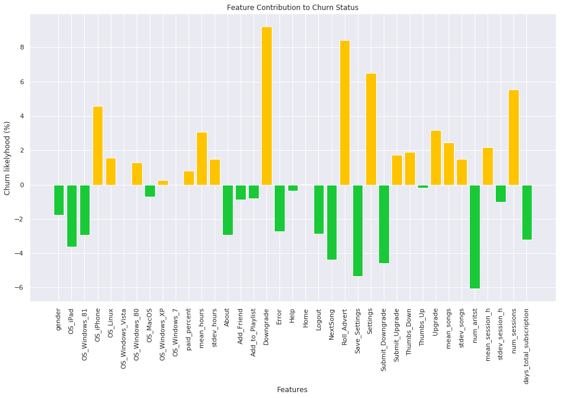

```python
# The Logistic Regression model

model = LogisticRegression()
param_grid = ParamGridBuilder() \
    .addGrid(model.regParam,[0.01, 0.1]) \
    .addGrid(model.elasticNetParam,[0.0, 0.5]) \
    .addGrid(model.aggregationDepth,[2, 5]) \
    .build()

m = model_fitting(train, model, param_grid, 'LogisticRegression.model')

# Model metrics
display(get_formated_metrics(m, test))

# Features effect
plot_feature_contributions(m, x_labels=features_labels)
```

```python
# The Decision Tree Classifier model

model = DecisionTreeClassifier()

param_grid = ParamGridBuilder() \
    .addGrid(model.maxDepth,[3, 5, 10]) \
    .addGrid(model.impurity,['entropy', 'gini']) \
    .build()

m = model_fitting(train, model, param_grid, 'DecisionTreeClassifier.model')
```

```
Fitting progress... Done in 31.61 second(s)

Saving model as DecisionTreeClassifier.model... *Overwritten* Time Remaining 0.36 second(s)
```

```python
# Uncomment if you want to load models only
features_labels = ['gender', 'OS_iPad', 'OS_iPhone', 'OS_Windows_81',
                   'OS_Linux', 'OS_Windows_Vista', 'OS_Windows_80',
                   'OS_MacOS', 'OS_Windows_XP', 'OS_Windows_7',
                   'paid_percent', 'mean_hours', 'stdev_hours',
                   'About', 'Add_Friend', 'Add_to_Playlist',
                   'Downgrade', 'Error', 'Help', 'Home', 'Logout',
                   'NextSong', 'Roll_Advert', 'Save_Settings',
                   'Settings', 'Submit_Downgrade', 'Submit_Upgrade',
                   'Thumbs_Down', 'Thumbs_Up', 'Upgrade', 'mean_songs',
                   'stdev_songs', 'num_aritst', 'mean_session_h',
                   'stdev_session_h', 'num_sessions',
                   'days_total_subscription']

len(features_labels)
```

```
37
```

```python
# to load the model from saved location
m = mlm.load('DecisionTreeClassifier.model')
```

```python
get_classification_metrics(m, train, test)
```

|  | Train | Test |
| --- | --- | --- |
| Accuracy | 0.892638 | 0.795082 |
| Precision | 1.000000 | 0.750000 |
| Recall | 0.469697 | 0.363636 |
| F-Score | 0.639175 | 0.489796 |

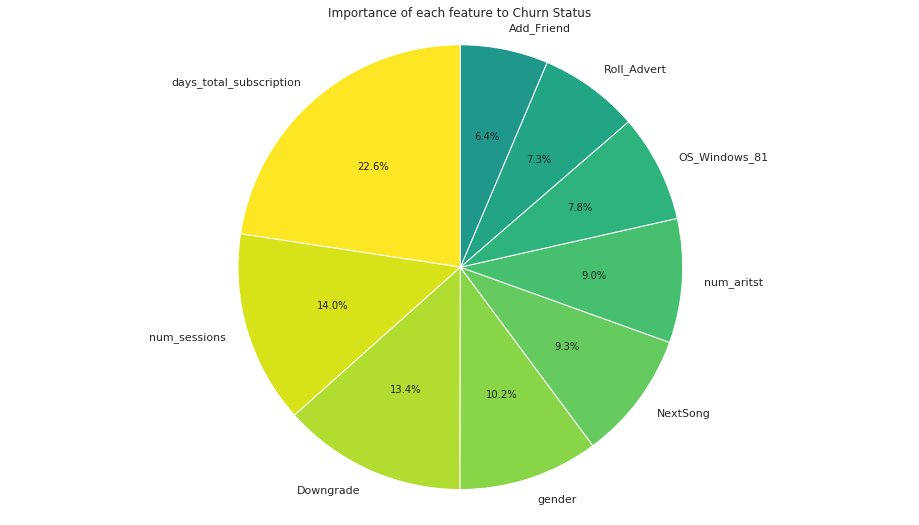

```python
plot_feature_importances(m, features_labels, threshold=3)
```

```python
# The Gradient-Boosted Trees (GBTs) model

model = GBTClassifier()
param_grid = ParamGridBuilder() \
    .addGrid(model.maxDepth,[3, 5, 10]) \
    .addGrid(model.maxBins ,[10, 5]) \
    .addGrid(model.maxIter ,[20, 5]) \
    .build()

m = model_fitting(train, model, param_grid, 'GradientBoostedTrees.model')
```

```
Fitting progress... Done in 7 minute(s) and 7.6 second(s)

Saving model as GradientBoostedTrees.model... *Overwritten* Time Remaining 0.73 second(s)
```

```python
# to load the model from saved location
m = mlm.load('GradientBoostedTrees.model')
```

```python
# Show metrics
display(get_classification_metrics(m, train, test))
```

|  | Train | Test |
| --- | --- | --- |
| Accuracy | 0.861963 | 0.745902 |
| Precision | 1.000000 | 0.571429 |
| Recall | 0.318182 | 0.242424 |
| F-Score | 0.482759 | 0.340426 |

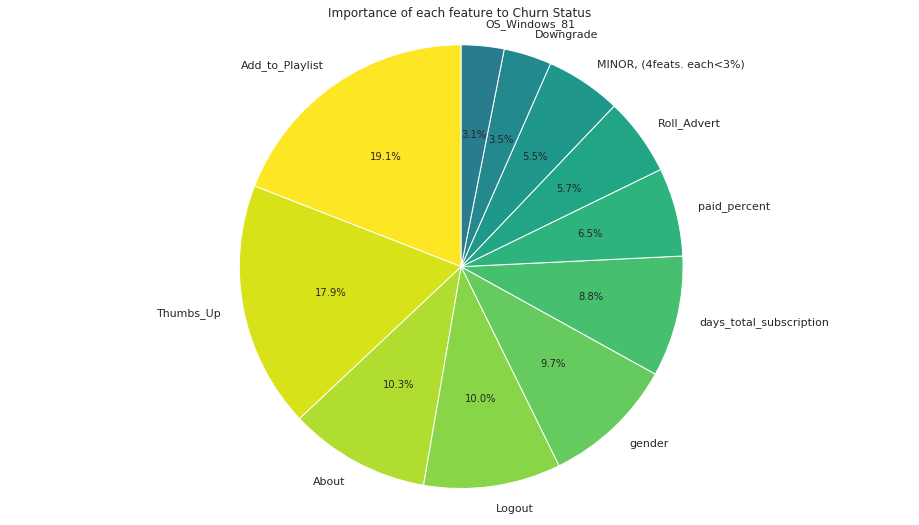

```python
plot_feature_importances(m, features_labels, threshold=3)
```

```python
# The Random Forest model

model = RandomForestClassifier()
param_grid = ParamGridBuilder() \
    .addGrid(model.maxDepth,[5, 10]) \
    .addGrid(model.impurity,['entropy', 'gini']) \
    .addGrid(model.maxBins ,[10, 5]) \
    .addGrid(model.numTrees ,[20, 10]) \
    .addGrid(model.featureSubsetStrategy ,['sqrt', 'onethird']) \
    .build()

m = model_fitting(train, model, param_grid, 'RandomForestClassifier.model')
```

```
Fitting progress... Done in 3 minute(s) and 3.85 second(s)

Saving model as RandomForestClassifier.model... *Overwritten* Time Remaining 0.9 second(s)
```

```python
# to load the model from saved location
m = mlm.load('RandomForestClassifier.model')
```

```python
# Show metrics
display(get_classification_metrics(m, train, test))
```

|  | Train | Test |
| --- | --- | --- |
| Accuracy | 0.978528 | 0.778689 |
| Precision | 1.000000 | 0.800000 |
| Recall | 0.893939 | 0.242424 |
| F-Score | 0.944000 | 0.372093 |

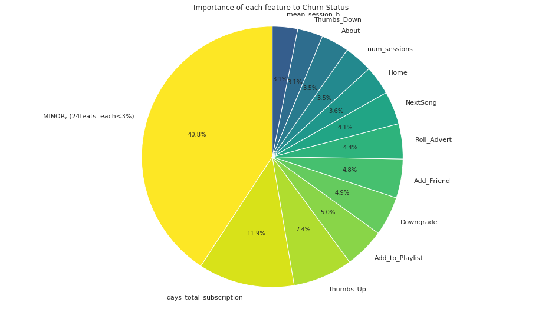

```python
plot_feature_importances(m, features_labels, threshold=3)
```

```python
# The Multilayer Perceptron Classifier model

model = MultilayerPerceptronClassifier()

param_grid = ParamGridBuilder() \
    .addGrid(model.blockSize,[64, 128]) \
    .addGrid(model.maxIter,[10, 20]) \
    .addGrid(model.stepSize ,[0.03, 0.01]) \
    .addGrid(model.solver ,['l-bfgs', 'gd']) \
    .addGrid(model.layers, [[37, 12, 2], [37, 5, 2]]) \
    .build()

m = model_fitting(train, model, param_grid, 'MultilayerPerceptronClassifier.model')
```

```
Fitting progress... Done in 2 minute(s) and 46.02 second(s)

Saving model as MultilayerPerceptronClassifier.model... *Overwritten* Time Remaining 0.67 second(s)
```

```python
display(get_classification_metrics(m, train, test))
```

|  | Train | Test |
| --- | --- | --- |
| Accuracy | 0.840491 | 0.696721 |
| Precision | 0.634615 | 0.441176 |
| Recall | 0.500000 | 0.454545 |
| F-Score | 0.559322 | 0.447761 |

# Final Steps

Clean up your code, adding comments and renaming variables to make the code easier to read and maintain. Refer to the Spark Project Overview page and Data Scientist Capstone Project Rubric to make sure you are including all components of the capstone project and meet all expectations. Remember, this includes thorough documentation in a README file in a Github repository, as well as a web app or blog post.

```python
# The Random Forest model

model = RandomForestClassifier()
param_grid = ParamGridBuilder() \
    .addGrid(model.maxDepth,[5]) \
    .addGrid(model.impurity,['gini']) \
    .addGrid(model.numTrees ,[120]) \
    .addGrid(model.featureSubsetStrategy ,['auto']) \
    .build()

m = model_fitting(train, model, param_grid, 'RandomForestClassifier.model')
```

```
Fitting progress... Done in 14.74 second(s)

Saving model as RandomForestClassifier.model... *Overwritten* Time Remaining 0.52 second(s)
```

```python
# to load the model from saved location
m = mlm.load('RandomForestClassifier.model')
```

```python
# Show metrics
display(get_classification_metrics(m, train, test))
```

|  | Train | Test |
| --- | --- | --- |
| Accuracy | 0.886503 | 0.745902 |
| Precision | 1.000000 | 0.625000 |
| Recall | 0.439394 | 0.151515 |
| F-Score | 0.610526 | 0.243902 |

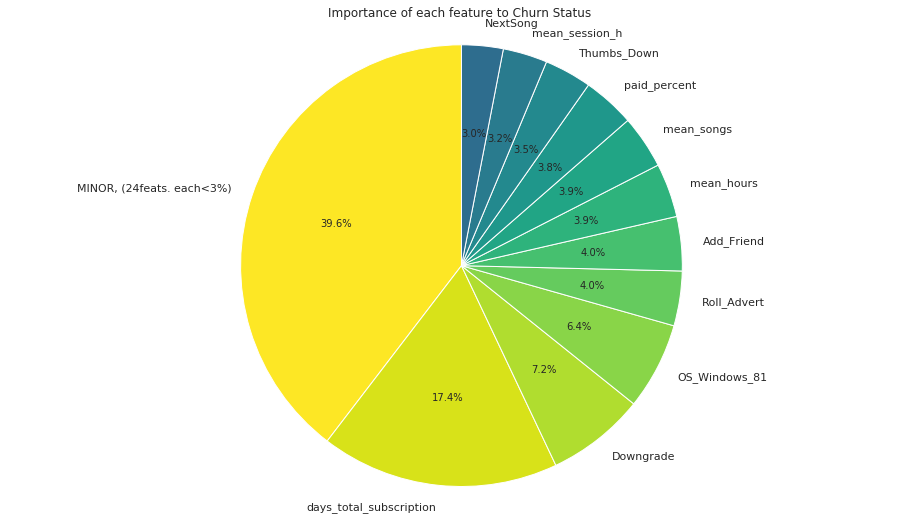

```python
plot_feature_importances(m, features_labels, threshold=3)
```